# Week 9 Learning Journal

Published

March 6, 2024

## Section 1: Projections

Tutorial name(s) and link(s):

[figure not shown]

College Town (Tutorial)

[figure not shown]

Teton Area Geo referencing

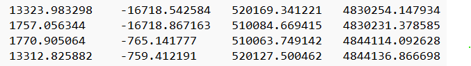

Control Point Table

**Geo-referencing Work Flow:**

1. Convert Image to jpg/tiff/png if not already in that form
2. Add Image to your map and using the imagery tab begin the georef process
3. Turn off auto apply (usually), and set SRS
4. Add control Points, starting with any known coordinates if available, otherwise…
5. using fit to display, scale, rotate, etc. adjust the image to the base map as best possible by eye, then add control points manually (using ‘L’ to swap views)
6. review the effects of the various transformation options
7. Save the Geo-referencing and export the control point table for safe keeping.